# Nonlinear Models

Lecture 6

Emre Yucel

University of Texas at Austin

2026-10-06

# Polynomial models

## Utilities data set

The data set `utilities` contains information on the natural gas bills for a house in Minnesota. We’ll focus on two variables:

- **dailyspend** is the average amount of money spent on natural gas (e.g. heating) for each day during the month
- **temp** is the average temperature outside for that month

## What assumption violation(s) do you see here?

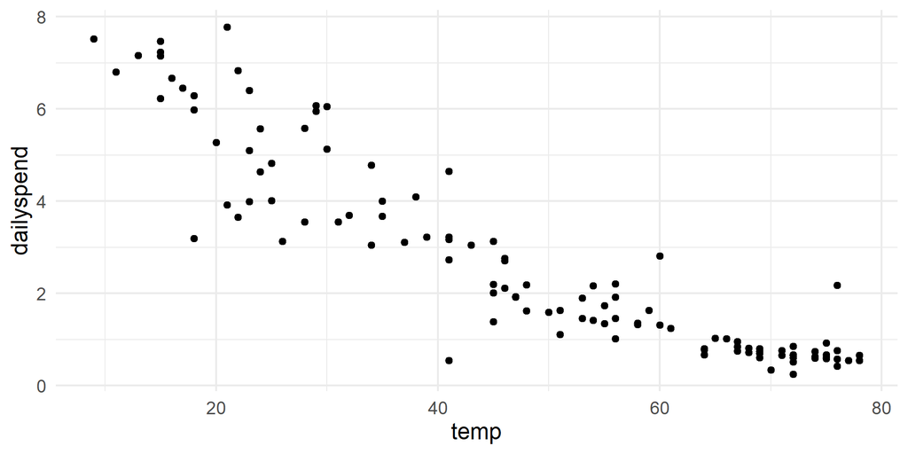

```
Call:
lm(formula = dailyspend ~ temp, data = utilities)

Residuals:
   Min     1Q Median     3Q    Max
-2.847 -0.504 -0.024  0.515  2.448

Coefficients:
            Estimate Std. Error t value Pr(>|t|)
(Intercept)  7.34762    0.20645    35.6   <2e-16 ***
temp        -0.09643    0.00391   -24.7   <2e-16 ***
---
Signif. codes:  0 '***' 0.001 '**' 0.01 '*' 0.05 '.' 0.1 ' ' 1

Residual standard error: 0.866 on 115 degrees of freedom
Multiple R-squared:  0.841, Adjusted R-squared:  0.84
F-statistic:  608 on 1 and 115 DF,  p-value: <2e-16
```

## Linearity and homoscedasticity are violated

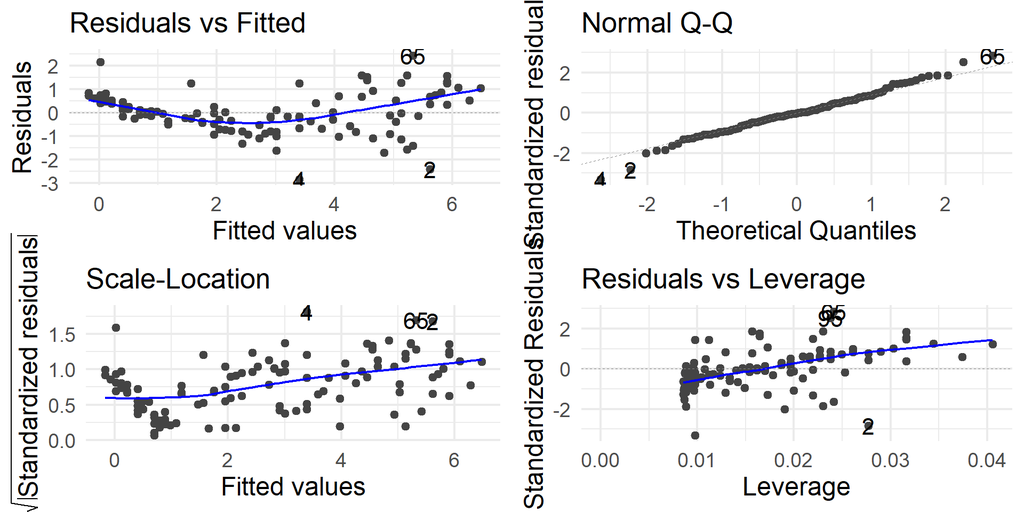

## Using polynomial regression to fix problems

- If a polynomial curve (e.g., quadratic, cubic, etc) would be a better fit for the data than a line, we can fit a curve to the data.
- The way we do this is by adding $X^2$ to the model as a second predictor variable.

```
Call:
lm(formula = dailyspend ~ temp + I(temp^2), data = utilities)

Residuals:
    Min      1Q  Median      3Q     Max
-2.8725 -0.2805 -0.0393  0.2639  2.1912

Coefficients:
             Estimate Std. Error t value    Pr(>|t|)
(Intercept)  9.472289   0.390789   24.24     < 2e-16 ***
temp        -0.211555   0.019105  -11.07     < 2e-16 ***
I(temp^2)    0.001248   0.000204    6.12 0.000000013 ***
---
Signif. codes:  0 '***' 0.001 '**' 0.01 '*' 0.05 '.' 0.1 ' ' 1

Residual standard error: 0.755 on 114 degrees of freedom
Multiple R-squared:  0.88,  Adjusted R-squared:  0.878
F-statistic:  419 on 2 and 114 DF,  p-value: <2e-16
```

## Writing out the equation

Writing out the equation:

$$\widehat{Y} = 9.4723 + -0.2116(\text{temp}) + 0.0012(\text{temp}^2)$$

Even though we’re fitting a parabola, it’s still a linear model since $Y$ is a linear function of $X$ and $X^2$!

## Adding an $X^2$ term fits a parabola to the data

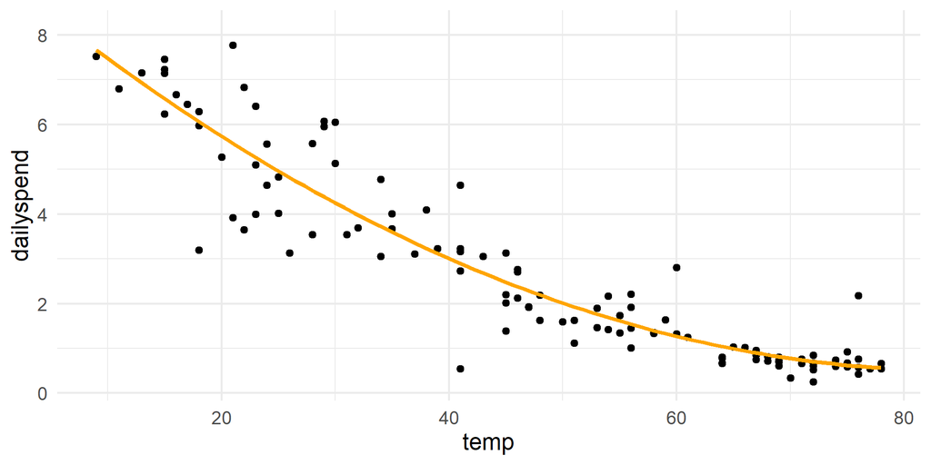

## It solves the linearity problem!

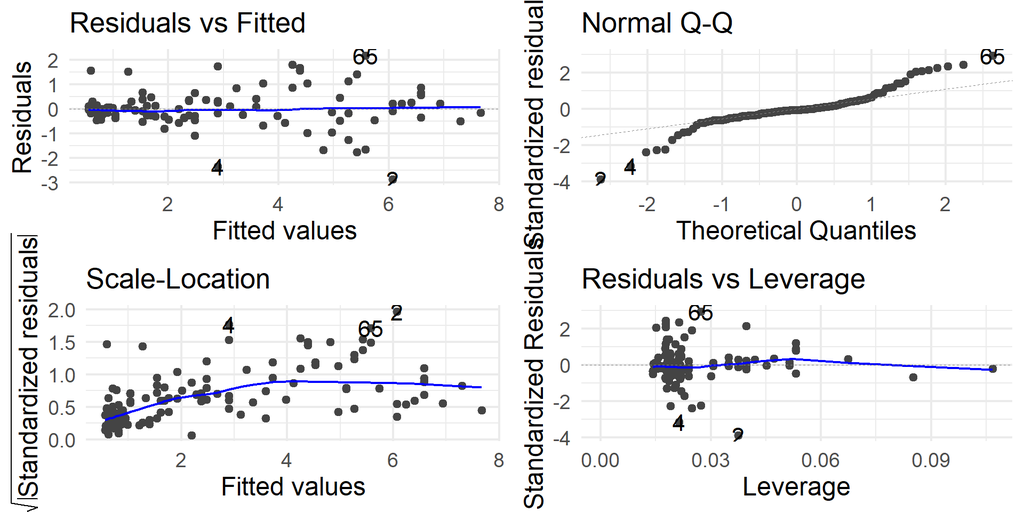

## What about a higher-order polynomial?

- We could fit a cubic curve by adding an $X^3$ term (in addition to the $X$ and $X^2$ terms)
- Making the polynomial higher order will increase $R^2$—why not go nuts and fit a 7th degree polynomial?

| Degree |  | $R^2$ |
| --- | --- | --- |
| 1 | linear | 0.841 |
| 2 | quadratic | 0.8803 |
| 3 | cubic | 0.8812 |
| 4 | quartic | 0.8813 |
| 5 |  | 0.8815 |
| 6 |  | 0.8822 |
| 7 |  | 0.8837 |

## Too high a degree “overfits” the data

**Overfitting** means the model follows the data *too* closely—including the random noise—so it doesn’t generalize well to new data. Think of memorizing answers for a test instead of understanding the concept: it works for those exact questions but fails on new ones.

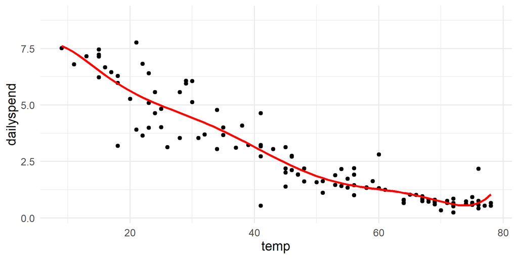

## Too high a degree creates dangers with extrapolation

**Extrapolation** = using the model to predict *outside* the range of X values we actually observed. For high-degree polynomials, the curve can swing wildly once you leave that range, so predictions become unreliable.

From Perusall:

> I understand that polynomial regression can capture curvature in the data, but why is extrapolation particularly risky in polynomial regression?

## Too high a degree creates dangers with extrapolation

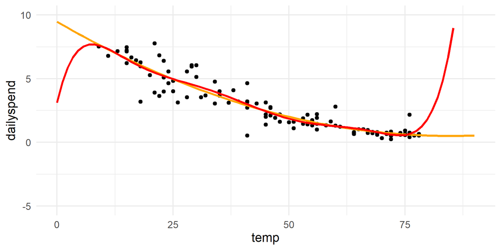

## Building polynomial models

From Perusall:

> Because linear regression models can have errors in the Residual vs. Fitted plot, how can we be sure that these models with curvature will provide a more accurate representation, besides examining the plot?

## Building polynomial models

- Start simple: only add higher-degree terms to the extent it gives you a substantial increase in $R^2$ (and is statistically significant), or satisfies an assumption hold that wasn’t satisfied before
- You must include lower-order terms: e.g., if you add $X^3$, you must also include $X$ and $X^2$
- Be careful about overfitting and extrapolating when adding higher-order terms!
- An $X^2$ term is an interaction of $X$ with itself: in a parabola, the slope depends on the value of $X$!

# Log-linear models

## Using transformations to fix problems

- Sometimes, a violation of regression assumptions can be fixed by transforming one or the other of the variables (or both).
- When we transform a variable, we have to also transform our interpretation of the equation.

## Moore’s Law

- Moore’s Law was a prediction made by Gordon Moore in 1965 (!) that the number of transistors on computer chips would double every 2 years.
- This implies **exponential** growth, so a linear model won’t fit well (and neither will any polynomial).

## Moore’s Law

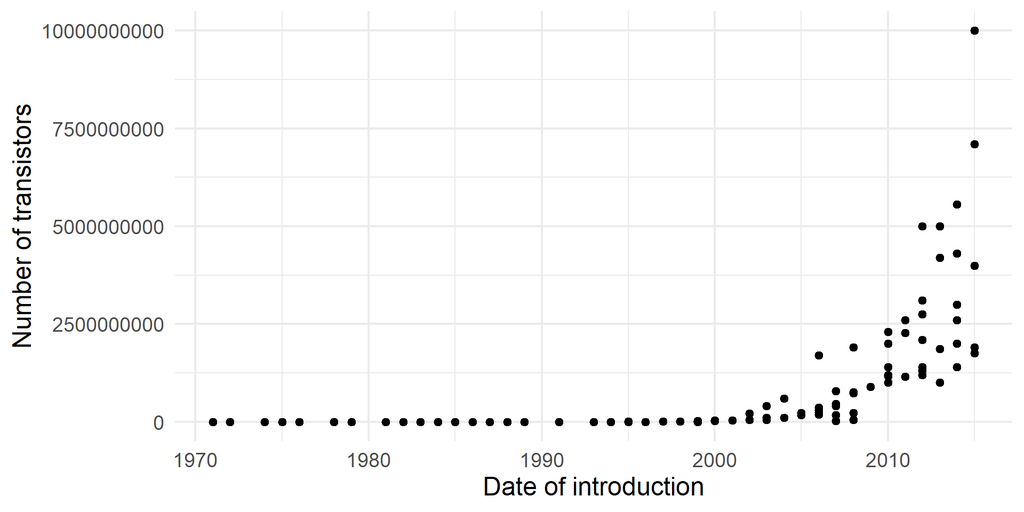

## A linear model fails the “L” assumption

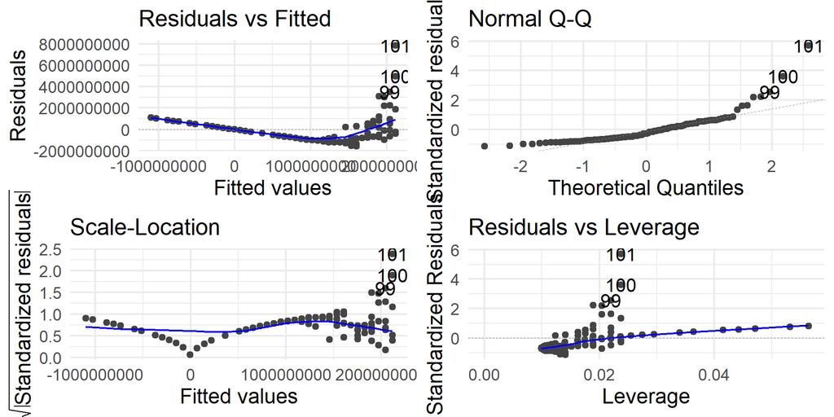

## The log transformation

- The **log** transformation is frequently useful in regression, because many nonlinear relationships are naturally exponential.
- In R, `exp(x)` calculates $e^x$ and `log(x)` calculates $\ln x$ — the natural log of $x$.
- When we write $\log x$, we mean $\ln x = \log_e x$.

## Modeling exponential growth

- If $Y = ae^{bX}$, then:
  $$\begin{align*}
  \log Y &= \log(ae^{bX}) \\
  &= \log(a) + \log(e^{bX}) \\
  &= \underbrace{\log(a)}_{\beta_0} + \underbrace{b}_{\beta_1}X
  \end{align*}$$
- In other words: if we think $Y$ is an exponential function of $X$, predict $\log Y$ as a linear function of $X$

## Transistors does NOT have a linear relationship with year

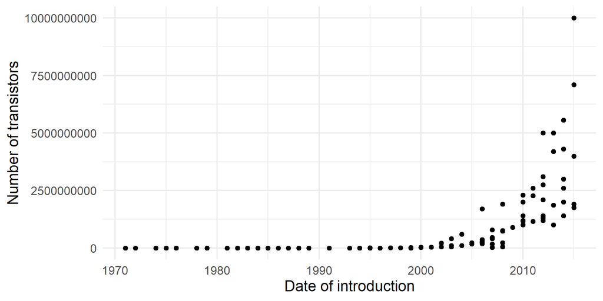

## But log(Transistors) *does* have a linear relationship with year

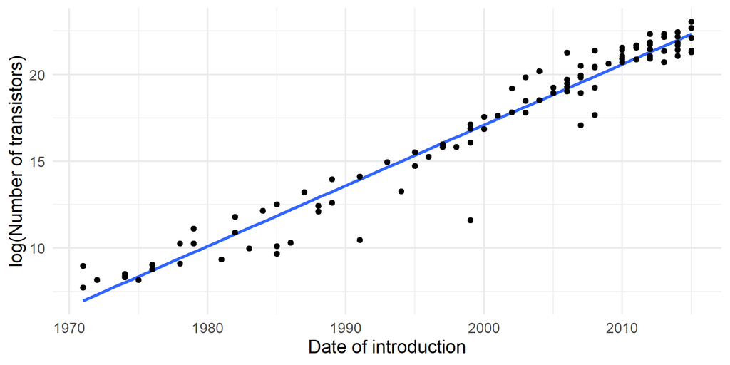

## A log-linear model satisfies the linearity assumption

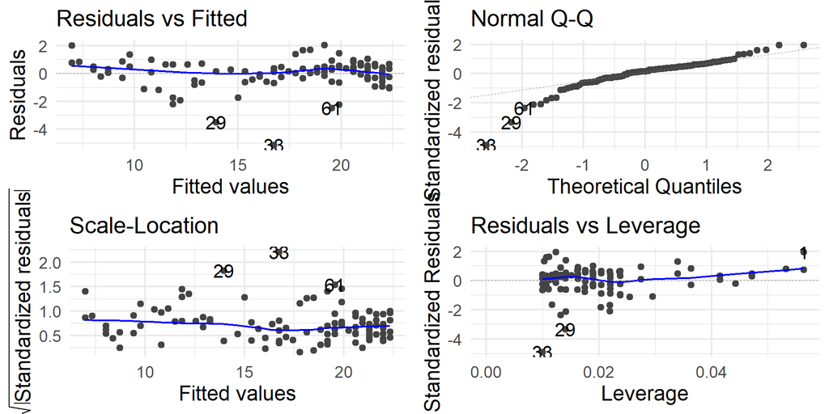

## Making predictions using the log-linear model

When making predictions, we have to remember that our equation gives us predictions for $\log Y$, not $Y$!

Example: To make a prediction for the number of transistors in 2025:

$$\log(\widehat{Y}) = -681.21 + 0.35(2025) = 25.83$$

To make a prediction, we have to solve for $\hat Y$:

$$\widehat{Y} = e^{\log(\widehat{Y})} = e^{25.83} = 1.64\times 10^{11}$$

## Making predictions using the log-linear model

```r
exp(predict(log.model, list(Date.of.introduction=2025),
            interval="prediction"))
```

```
           fit         lwr           upr
1 164341865197 19321959793 1397800686137
```

## Interpreting the log-linear model

From Perusall:

> Because taking the log of this function only impacts the relationship between the logarithms of the variables, does this impact how we interpret the predictor values as well? Would using this model mean that our interpretations are only applicable to the logarithmic confidence interval etc.?

## Interpreting the log-linear model

Our model is
$$\log(\widehat{Y}) = -681.21 + 0.35\cdot\text{Year}$$

$$\widehat{Y} = e^{-681.21 + 0.35\cdot\text{Year}}$$

Two interpretations of the slope coefficient:

- Every year, the predicted log of transistors increases by 0.35.
- **More useful:** Every year, the predicted number of transistors is *multiplied* by $e^{0.35} = 1.42$ (i.e., a 42% increase).
- A constant *percentage* increase every year (rather than a constant *amount*) is what we mean by *exponential* growth.

## Interpreting the log-linear model

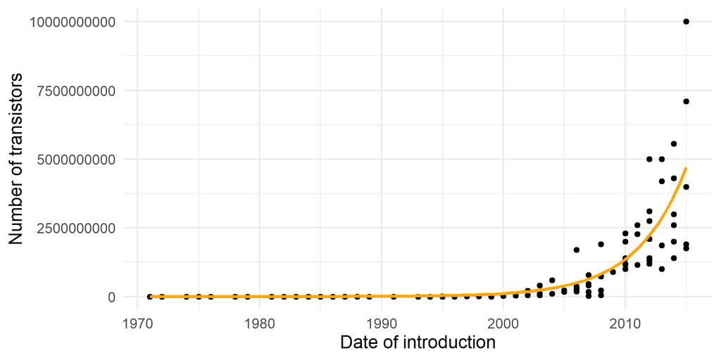

## When is the log transformation useful?

- You can transform $X\to\log(X)$, $Y\to\log(Y)$, or both.
- Anytime you need to “squash” one of the variables (logs make huge numbers, like transistors, not so big!), try transforming it with a log.
- You may need to do a little bit of trial and error to see what works best.
- Other transformations are possible! For example, $X \to \sqrt{X}$, or $X \to 1/X$.

## Approximate slope interpretations in the presence of logs

(These approximations work best when $\hat\beta_1$ is small.)

| Model | Equation | Interpretation |
| --- | --- | --- |
| Linear | $\hat Y = \hat\beta_0 + \hat\beta_1 X$ | 1 unit increase in $X$ $\to$ $\hat\beta_1$ unit increase in $\hat Y$ |
| Log-linear | $\log(\hat Y) = \hat\beta_0 + \hat\beta_1 X$ | 1 unit increase in $X$ $\to$ $\approx [100 (e^{\hat\beta_1}-1)]$% increase in $\hat Y$ |
| Linear-log | $\hat Y = \hat\beta_0 + \hat\beta_1 \log(X)$ | 1% increase in $X$ $\to$ $\approx 0.01\hat\beta_1$ unit increase in $\hat Y$ |
| Log-log | $\log(\hat Y) = \hat\beta_0 + \hat\beta_1 \log(X)$ | 1% increase in $X$ $\to$ $\approx \hat\beta_1$% increase in $\hat Y$ |

## Approximate slope interpretations in the presence of logs

| Model | Example | Interpretation |
| --- | --- | --- |
| Linear | $\hat Y = -681 + 0.35X$ | 1 unit increase in $X$ $\to$ 0.35 unit increase in $\hat Y$ |
| Log-linear | $\log(\hat Y) = -681 + 0.35X$ | 1 unit increase in $X$ $\to$ $\approx 42$% increase in $\hat Y$ ($e^{0.35} \approx 1.42$) |
| Linear-log | $\hat Y = -681 + 0.35\, \log(X)$ | 1% increase in $X$ $\to$ $\approx 0.0035$ unit increase in $\hat Y$ |
| Log-log | $\log(\hat Y) = -681 + 0.35\, \log(X)$ | 1% increase in $X$ $\to$ $\approx 0.35$% increase in $\hat Y$ |

# Log-log models

## An elasticity interpretation for log-log models

- The beer data set contains sales data for cases of beer sold at a supermarket chain
- PRICE18PK is the price of 18-packs, and CASES18PK is the number of 18-packs sold
- There are also variables for 12-packs and 30-packs

## What is price elasticity?

- **Price elasticity** answers: “If we raise price by 1%, by what percent does quantity sold change?” It’s the ratio:
  $$\begin{align*}
  \text{elasticity} &= \frac{\text{\% change in demand}}{\text{\% change in price}}
  \end{align*}$$
- In a **log-log** model, the slope coefficient tells us exactly that: the (approximate) percent change in $Y$ when $X$ increases by 1%. So the slope *is* the elasticity.

## Fitting a demand curve

We essentially need to fit a demand curve—will a linear model work?

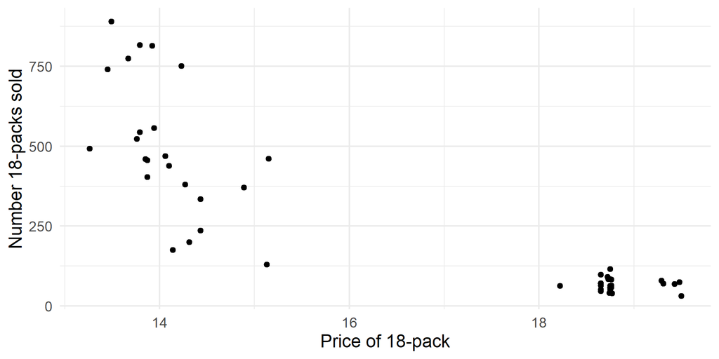

## Fitting a demand curve

A log-log model will work:

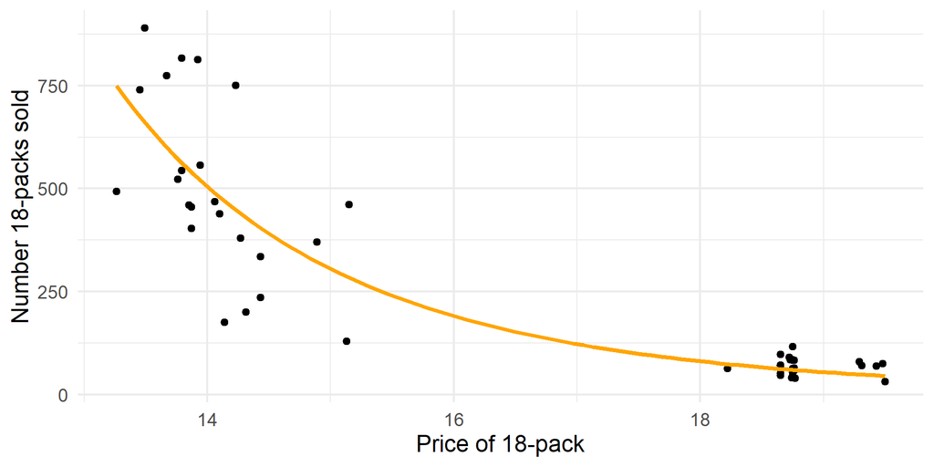

## Price elasticity of 18 packs

A 1% increase in price is associated with about a 6.7% *decrease* in predicted sales. When quantity responds a lot to a small price change, we say the good is **elastic** (people can switch to other drinks); when quantity barely changes, we say **inelastic** (e.g., necessities with few substitutes).

```
Call:
lm(formula = log(CASES18PK) ~ log(PRICE18PK), data = beer)

Residuals:
    Min      1Q  Median      3Q     Max
-0.8986 -0.2043 -0.0013  0.2665  0.5948

Coefficients:
               Estimate Std. Error t value Pr(>|t|)
(Intercept)      23.831      0.946    25.2   <2e-16 ***
log(PRICE18PK)   -6.705      0.337   -19.9   <2e-16 ***
---
Signif. codes:  0 '***' 0.001 '**' 0.01 '*' 0.05 '.' 0.1 ' ' 1

Residual standard error: 0.36 on 50 degrees of freedom
Multiple R-squared:  0.888, Adjusted R-squared:  0.886
F-statistic:  397 on 1 and 50 DF,  p-value: <2e-16
```

## Log transformations can also fix violations of the “E” assumption!

Compare the scale-location plots for the linear model (left) vs the log-log model (right):

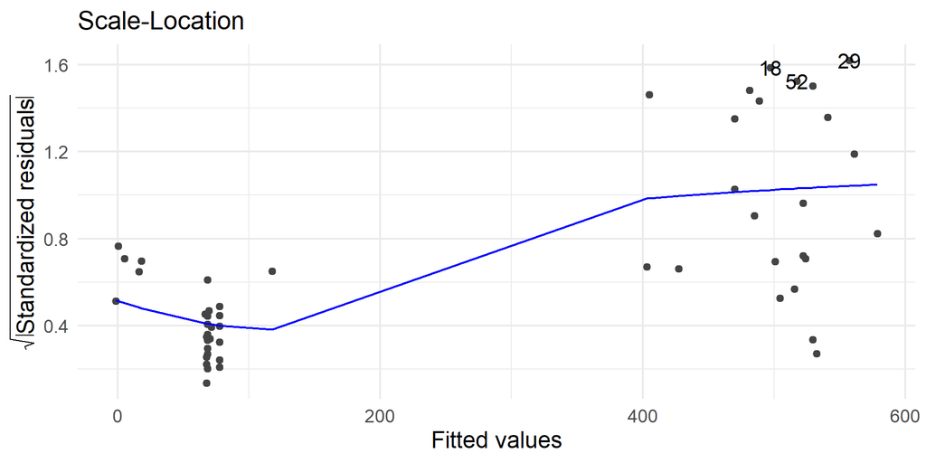

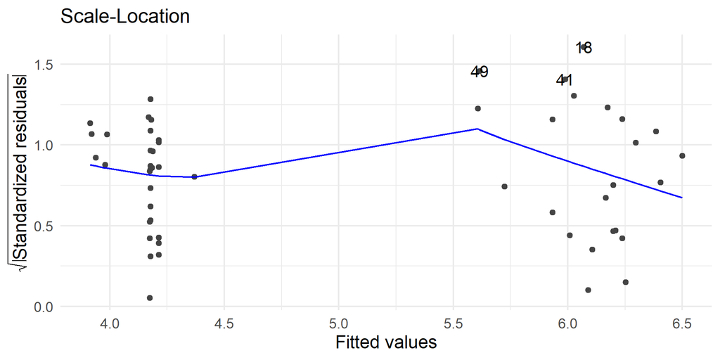